# Mathematical Spaces

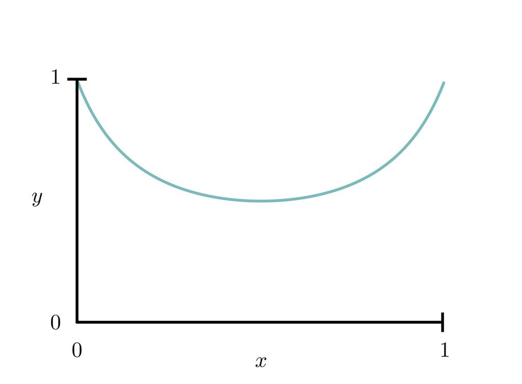

(a)

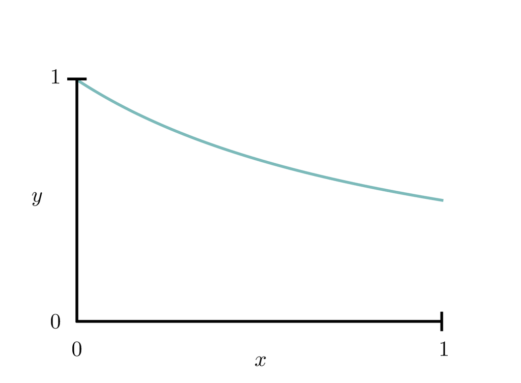

(b)

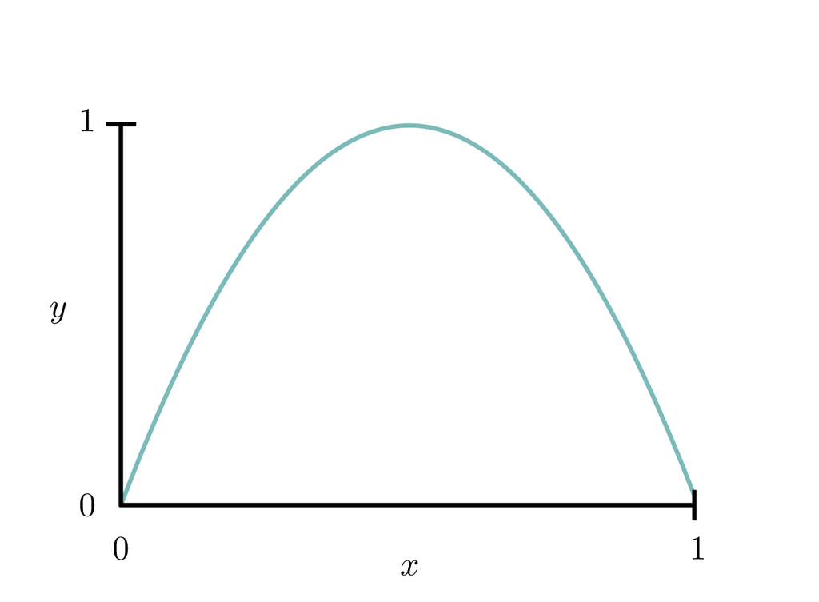

(c)

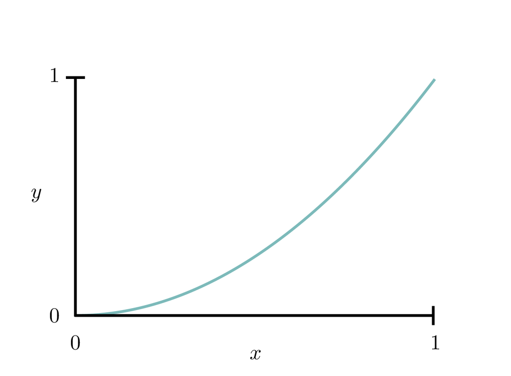

(d)

Figure 21: Injective functions map distinct input elements to distinct output elements, while surjective functions map into every output element at least once. Here (a) is neither injective nor surjective, (b) is injective but not surjective, (c) is not injective but is surjective, and (d) is both injective and surjective.

The function (Figure 21 (a))
$$\begin{alignat*}{6}
f_1 :\; & [0, 1] & &\rightarrow& \; & [0, 1] &
\\
& x & &\mapsto& & \frac{1}{1 + 4 \cdot x \cdot (1 - x)} &
\end{alignat*}$$
is not injective because both $x$ and $1 - x$ map to the same output element. Moreover, it is not surjective because no input element will ever yield an output less than $y = \frac{1}{2}$.

Like $f_1$, the function (Figure 21 (b))
$$\begin{alignat*}{6}
f_2 :\; & [0, 1] & &\rightarrow& \; & [0, 1] &
\\
& x & &\mapsto& & \frac{1}{1 + x} &
\end{alignat*}$$
outputs only values larger than or equal to $y = \frac{1}{2}$, and hence is not surjective. On the other hand, each distinct input element maps to a distinct output element so, unlike the function $f_1$, the function $f_2$ is injective.

Finally, the function (Figure 21 (d))
$$\begin{alignat*}{6}
f_4 :\; & [0, 1] & &\rightarrow& \; & [0, 1] &
\\
& x & &\mapsto& & x \cdot x &
\end{alignat*}$$
is both injective *and* surjective, and hence bijective.

Functions that map the input set into itself, $f : X \rightarrow X$, are known as **automorphisms**. A bijective automorphism doesn’t change $X$, but may permute its elements around. This permutation can in turn warp any structure endowed on $X$.

The **identity function** is the unique bijective automorphism that maps every element $x \in X$ back to itself,
$$\begin{alignat*}{6}
\text{Id} :\; & X & &\rightarrow& \; & X &
\\
& x & &\mapsto& & x &,
\end{alignat*}$$
leaving the set completely unchanged. When working with algebraic spaces we have to be careful to distinguish between the identity *function* that maps an input set into itself and the identity *element* of that set.

### 3.1.2 Function Inverses

Bijective functions are particularly special because we can always undo their action and recover input elements. Formally, if $f : X \rightarrow Y$ is a bijection then we can define an **inverse function** $f^{-1} : Y \rightarrow X$ such that
$$f^{-1}(f(x)) = x$$
for all $x \in X$. Because no information is lost when we map from $X$ to $Y$, we can completely recover $X$ again if needed (Figure 22).

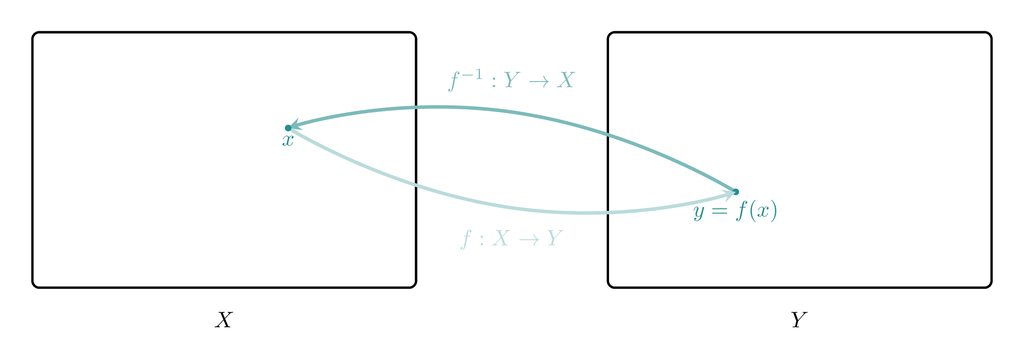

Figure 22: A bijective function $f$ identifies every output element with one and only input element. Consequently, we can construct an inverse function that takes each output element back to the corresponding input element.

As with the term “identity” we have to be careful when using the term “inverse” in the context of algebraic spaces. Specifically, we have to take care to distinguish between inverse *functions* between two sets and inverse *elements* in either of those two sets.

Without bijectivity, we cannot define inverse functions that map distinct output elements to distinct input elements. If a function is not surjective, then some output elements might not be related to *any* input elements. On the other hand, if a function is not injective then some output elements may be related to *multiple* input elements.

Although we cannot generally relate elements $y \in Y$ to unique elements of $X$, we can relate them to the *subsets* of $X$ that contain all of the elements that map into $y$,
$$f^{-1}(y) = \{ x \in X \mid f(x) = y \} \subset X.$$
The subset $f^{-1}(y)$ is referred to as the *level set* or *fiber* of $y$. Intuitively, we can reconstruct the entire input set by “weaving” these fibers together,
$$X = \cup_{y \in Y} f^{-1}(y).$$

If $f$ is not surjective then some level sets will be empty, but if $f$ is surjective then all level sets will be non-empty. At the same time, the level sets of non-injective functions will generally contain multiple elements while the level sets of injective functions will contain a single element or no elements. The level sets of bijective functions contain one and only one element: the result of evaluating the inverse function.

Level sets allow us to define a generalized notion of inversion for arbitrary functions, where we map output elements to their corresponding level set (Figure 23),
$$\begin{alignat*}{6}
f^{-1} :\; & Y & &\rightarrow& \; & 2^X &
\\
& y & &\mapsto& & f^{-1}(y) &.
\end{alignat*}$$

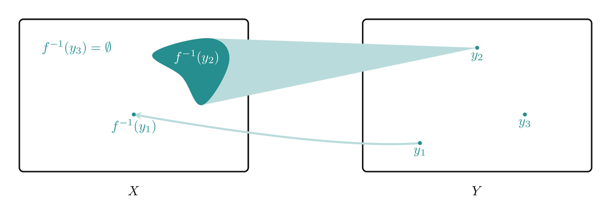

Figure 23: Even if a function is not bijective, we can define a generalized inverse that maps each output element $y \in Y$ to a level set, or fiber, of input elements $f^{-1}(y) \subset X$. In general, these level sets can be empty, consist of a single input element, or consist of multiple input elements.

### 3.1.3 Function Composition

When formalizing the defining property of an inverse function, we took the output of a function $y = f(x)$ and used it as input to the inverse function, $f^{-1}(y) = f^{-1}(f(x))$. This chaining of functions with compatible input and output sets is known as **function composition**, or just **composition** for short.

More formally, given the functions $f : X \rightarrow Y$ and $g : Y \rightarrow Z$ we can construct the composition of $f$ with $g$ as the function
$$\begin{alignat*}{6}
g \circ f :\; & X & &\rightarrow& \; & Z &
\\
& x & &\mapsto& & z = g(f(x)) &.
\end{alignat*}$$

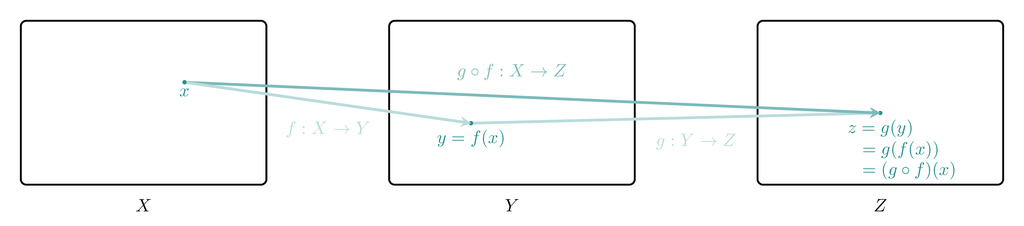

Figure 24: The functions $f : X \rightarrow Y$ and $g : Y \rightarrow Z$ can be chained together, mapping an input element $x \in X$ to an intermediate element $y \in Y$ which is then mapped to an output element $z \in Z$. This combined mapping defines the composite function $g \circ f$.

Using this notation, we can define an inverse function a bit more compactly as the unique function satisfying the composition condition
$$\text{Id} = f^{-1} \circ f.$$
In words, the composition of a bijective function with its inverse function must be the identify function.

## 3.2 Relating Structures

Functions define how the elements of an input set transform into the elements of an output set. If we want to relate entire *spaces*, however, then we also need to specify how the additional structures that define those spaces transform along with the underlying elements.

To be more precise, let $\mathfrak{x}$ denote whatever structure we endow on the set $X$ so that our input space is fully described as $(X, \mathfrak{x})$. In order to fully define an output space, we need to map input elements in $X$ to output elements in $Y$ *and* equip that output space with some structure $\mathfrak{y}$. We can choose that structure arbitrarily, or we can try to derive it from the input structure $\mathfrak{x}$.

Fortunately, maps between sets often *induce* natural maps between structures. This allows us to fully transform spaces without having to make additional assumptions about associated structures. Unfortunately, these induced maps don’t always give the structure that we might expect.

### 3.2.1 Pushforward and Pullback Relations

Consider a function $f : X \rightarrow Y$ that maps input elements into output elements, and a subset of the input space $\mathsf{x} \subset X$. Applying $f$ to each element of $\mathsf{x}$ defines a subset of the output space $\mathsf{y} \subset Y$,
$$\mathsf{y}
=
\{ y \in Y \mid y = f(x) \text{ for some } x \in \mathsf{x} \}.$$
In other words, the element-wise evaluation of $f$ implicitly defines a map from input subsets to output subsets (Figure 25 (a))
$$\begin{alignat*}{6}
f_{*} :\; & 2^X & &\rightarrow& \; & 2^Y &
\\
& \mathsf{x} & &\mapsto& & \mathsf{y} = f_{*}(\mathsf{x}) &.
\end{alignat*}$$
These output subsets are often referred to as the **image** of the corresponding input subset.

If $f$ is not bijective, then we cannot map output elements to unique input elements. We can, however, always map every output element to a, possibly empty, collection of input elements $f^{-1}(y) \subset X$. The union of the level sets from all elements in an output subset $\mathsf{y} \subset Y$ defines a subset of all of the input elements that map into $\mathsf{y}$,
$$\mathsf{x} = \bigcup_{y \in \mathsf{y}} f^{-1}(y) \subset X,$$
or, equivalently,
$$\mathsf{x} = \{ x \in X \mid f(x) \in \mathsf{y} \}.$$
Weaving together these level sets implicitly defines a map from output subsets to input subsets (Figure 25 (b)),
$$\begin{alignat*}{6}
f^{*} :\; & 2^Y & &\rightarrow& \; & 2^X &
\\
& \mathsf{y} & &\mapsto& & \mathsf{x} = f^{*}(\mathsf{y}) &.
\end{alignat*}$$
These input subsets are often referred to as the **inverse image** or **preimage** of the corresponding output subset.

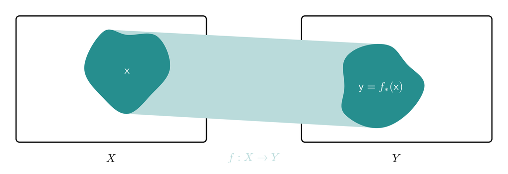

(a)

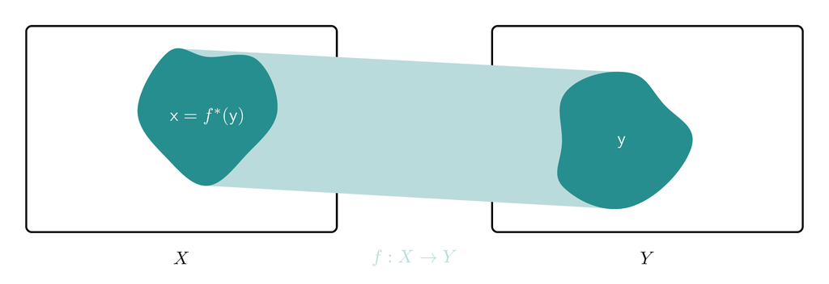

(b)

Figure 25: The action of a function $f$ on individual elements induces an action on entire subsets. In particular we can construct (a) a map from input subsets to output subsets and (b) a map from output subsets to input subsets.

This pattern is not exceptional. Sufficiently well-behaved functions that map an input set into an output set often induce mappings from objects defined over that input set to objects defined over that output set or vice versa. This includes not only subsets but also all of the structures that elevate a set into a space that we introduced in Section 1.2.

To be a bit more formal, let $X$ be the set defining an input space and $\mathfrak{x}$ the particular structure, or structures, that elevates that set into a space; in this case, we can completely specify our space as $(X, \mathfrak{x})$. Moreover, denote the set of all structures that we can endow onto the input space $X$ as $\mathfrak{X}$, and the set of all structures that we can endow onto the output space $Y$ as $\mathfrak{Y}$.

The subset map $f_{*} : 2^X \rightarrow 2^Y$ that we constructed above *pushes* inputs subsets *forward* along the action of the function $f$. Analogously, any relation induced by $f : X \rightarrow Y$ that pushes input structures forward into compatible output structures,
$$\begin{alignat*}{6}
f_{*} :\; & \mathfrak{X} & &\rightarrow& \; & \mathfrak{Y} &
\\
& \mathfrak{x} & &\mapsto& & \mathfrak{y} &,
\end{alignat*}$$
is denoted a **pushforward function along $f$**. When the underlying function $f$ is unambiguous then we also sometimes refer to $f_{*}$ as a **pushforward function**.

As with functions that act on sets, we have to be careful to distinguish between pushforward *functions*, $f_{*} : \mathfrak{X} \rightarrow \mathfrak{Y}$, and the particular pushforward *structure* defined by evaluating the pushforward function on a given input structure, $f_{*}(\mathfrak{x})$. If there might be any ambiguity then we have to be careful to use “pushforward” as an adjective, explicitly modifying “function” or “structure”, and not an ambiguous noun.

Similarly, the subset map $f^{*} : 2^Y \rightarrow 2^X$ that we constructed above *pulls* output subsets *back* against the action of the function $f$. More generally, any relation induced by $f : X \rightarrow Y$ that pulls output structures back into compatible input structures,
$$\begin{alignat*}{6}
f^{*} :\; & \mathfrak{Y} & &\rightarrow& \; & \mathfrak{X} &
\\
& \mathfrak{y} & &\mapsto& & \mathfrak{x} &,
\end{alignat*}$$
is denoted a **pullback function against $f$**. When the underlying function $f$ is unambiguous then we also sometimes refer to $f^{*}$ as a **pullback function**.

The existence of pushforward and pullback functions depends on how the defining function $f : X \rightarrow Y$ interacts with the relevant structure. In general, the nicer the function $f$ is the more structure-transforming functions it induces.

#### 3.2.1.1 Relating Orderings

A function $f : X \rightarrow Y$ allows us to implicitly compare two input elements by explicitly comparing their output values. In other words, we can pull back output comparisons to input comparisons.

Consider, for example, orderings. If the output space $Y$ is equipped with a partial ordering $<_{Y}$, then for any function $f$ we can define a partial ordering on the input space as
$$x_{1} \;\; (f^{*}\!\!<_{Y}) \; x_{2}$$
if and only if
$$f(x_{1}) <_{Y} f(x_{2}).$$

Pulling back strict orderings requires a bit more care. In general, distinct input elements can map to the same output element,
$$f(x_{1}) = f(x_{2}),$$
making any strict ordering between $x_{1}$ and $x_{2}$ ambiguous. Only when $f$ is injective will we be able to define a consistent strict ordering on the input space. That said, these ambiguous comparisons still define a perfectly well-behaved *partial* ordering on the input set.

To review, an arbitrary function $f : X \rightarrow Y$ pulls back *any* ordering on the output space to a partial ordering on the input space. Injective functions in particular also pull back strict orderings on the output space to strict orderings on the input space.

Pushing forward orderings from the input space to the output space is not quite as easy as pulling back orderings. If any pair of output elements are associated with multiple input elements,
$$\begin{align*}
y_{1} &= f(x_1) = f(x_1')
\\
y_{2} &= f(x_2) = f(x_2'),
\end{align*}$$
then we can have conflicting input orderings,
$$\begin{align*}
x_1 &< x_2
\\
x_2' &< x_1',
\end{align*}$$
that cannot be reconciled into a consistent output ordering.

#### 3.2.1.2 Relating Algebras

Algebraic structure is a bit more difficult to translate. Consider, for example, a binary algebraic operation that takes two elements from a set and returns a single element. In order to pushforward an operation $\cdot$ on the input space, we would need to map output elements to input elements, apply the operation, and then map the result back to the output space,
$$y_1 \; (f_{*} \cdot) \; y_2
\equiv
f \left( f^{-1}(y_1) \cdot f^{-1}(y_2) \right).$$
If $f$ is not bijective, however, then the inverse function evaluations will be ill-defined.

Similarly, in order to pullback an operation $\cdot$ on the output space, we would need to map input elements to output elements, apply the operation, and then map the result back to the input space,
$$x_1 \; (f^{*} \cdot) \; x_2
\equiv
f^{-1} \left( f(x_1) \cdot f(y_2) \right).$$
An injective function is sufficient for the first two steps to be well-defined, but we still need $f$ to be bijective in order for the last step to also be well-defined.

To summarize, we can pushforward and pullback binary algebraic operations only when $f$ is a bijection.

#### 3.2.1.3 Relating Metrics

Metrics are a bit more forgiving. Applying $f : X \rightarrow Y$ to two input elements defines two output elements that we can plug into a metric defined over the output set,
$$(f^{*} d)(x_1, x_2) \equiv d(f(x_1), f(x_2)).$$
This composition, however, does not always define a proper metric over the input set!

In particular, if $f$ is not injective then $d(f(x_1), f(x_2))$ can vanish even if $x_1 \ne x_2$. Fortunately, if $f$ is injective then $(f^{*} d)(x_1, x_2)$ will satisfy all of the properties of a metric on the input set. In this case we we denote it the **pullback metric**.

#### 3.2.1.4 Relating Topologies

Finally, let’s consider how we might translate topologies across a function. Using the map from input subsets to output subsets that we constructed above, we can map the collection of subsets that define a topology on the input set,
$$\mathfrak{t}_{X}
=
\{ \mathsf{x}_{1}, \ldots, \mathsf{x}_{i}, \ldots \},$$
into a collection of subsets in the output set,
$$\{
f^{*}(\mathsf{x}_{1}), \ldots, f^{*}(\mathsf{x}_{i}), \ldots
\}.$$

This output collection, however, will not always satisfy the properties of a topology. For example, if $f$ it not surjective then the output collection will not contain the full set as needed. Even if $f$ is surjective, the pushforward sets are not guaranteed to be closed under intersections and hence will not, in general, define a topology.

### 3.2.2 Bijective Pushforwards and Pullbacks Relations

The asymmetry between the availability of pushforward and pullback actions for different structures can be frustrating in practice, especially when an application supplies structure on the wrong set. Fortunately, this asymmetry washes away when we consider bijective functions and their inverses.

Consider, for example, some structure that only pulls back against a function,
$$f^{*} : \mathfrak{Y} \rightarrow \mathfrak{X}.$$
If $f$ is bijective then we can also pullback that structure against the inverse function,
$$(f^{-1})^{*} : \mathfrak{X} \rightarrow \mathfrak{Y}.$$
This implicitly pushes structure defined on $X$ forward to structure defined on $Y$.

Similarly, if we have some structure that only pushes forward along a function,
$$f_{*} : \mathfrak{X} \rightarrow \mathfrak{Y},$$
then we can use the pushforward along the inverse function,
$$(f^{-1})_{*} : \mathfrak{Y} \rightarrow \mathfrak{X},$$
to pullback structure defined on $Y$ to structure defined on $X$.

Importantly these induces transformations are also inverses,
$$\begin{align*}
f^{*} \circ (f^{-1})^{*} &= \mathrm{Id}_{\mathfrak{X}}
\\
(f^{-1})^{*} \circ f^{*} &= \mathrm{Id}_{\mathfrak{Y}}
\\
(f^{-1})_{*} \circ f_{*} &= \mathrm{Id}_{\mathfrak{X}}
\\
f_{*} \circ (f^{-1})_{*} &= \mathrm{Id}_{\mathfrak{Y}}.
\end{align*}$$
In other words, bijective functions allow us to move back and forth between the input space and the output space without losing information about the individual elements or any structure endowed to those elements!

### 3.2.3 Structure-Preserving Relations

Pushforward and pullback functions allow us to *lift* a transformation between sets into a transformation between spaces. For structure that can be pushed forward along the function $f : X \rightarrow Y$, any input space $(X, \mathfrak{x})$ automatically defines a compatible output space $(Y, f_{*}(\mathfrak{x}))$. Similarly, for any structure that can be pulled back against $f$, any output space $(Y, \mathfrak{y})$ automatically defines a compatible input space $(X, f^{*}(\mathfrak{y}))$.

Many applications, however, specify not just an input space $(X, \mathfrak{x})$ or an output space $(Y, \mathfrak{y})$ but rather *both* input and output spaces. In this case, pushforward structure may not be compatible with the structure that has already been endowed on the output space,
$$f_{*}(\mathfrak{x}) \ne \mathfrak{y},$$
and pullback structure may not be compatible with the structure that has already been endowed on the input space,
$$f^{*}(\mathfrak{y}) \ne \mathfrak{x}.$$
The exceptional functions that yield compatible pushforward and/or pullback structure are known as **structure-preserving transformations**. Structure-preserving bijections in particular are also known as **isomorphisms**.

#### 3.2.3.1 Ordering-Preserving Relations

For instance, consider a strictly ordered input space $(X, <{X})$ and a strictly ordered output space $(Y, <{Y})$. Any injective function $f: X \rightarrow Y$ defines a pullback strict ordering $f^{*} \!\! <{Y}$ on the input space by
$$x_{1} \;\; (f^{*}\!\!<_{Y}) \; x_{2}$$
if and only if
$$f(x_{1}) <_{Y} f(x_{2}).$$
There’s no guarantee, however, that this will be consistent with the initial ordering $<{X}$. Instead, we will have $f_{*} <{Y} = <{X}$ only for the exceptional functions satisfying
$$f(x_{1}) <{Y} f(x_{2})$$
if and only if
$$x_{1} <{X} x_{2}.$$
These injective functions are known as **monotonically increasing functions**. Injective functions that *flip* the orientation of the orderings, so that
$$f(x_{1}) <{Y} f(x_{2})$$
if and only if
$$x_{2} <{X} x_{1}$$
are known as **monotonically decreasing functions**.

More generally, functions that respect a *partial* ordering on the input space and any ordering on the output space are known as **monotonically non-decreasing functions**. Those that reverse the orientation of the partial orderings are known as **monotonically non-increasing functions**.

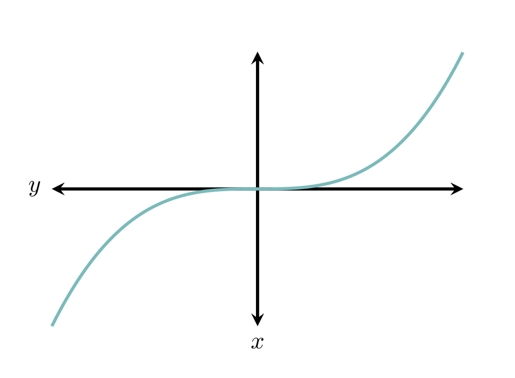

(a)

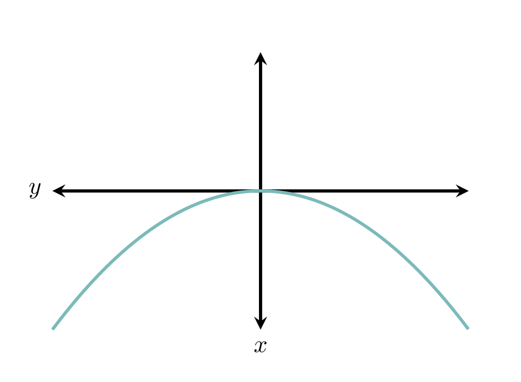

(b)

Figure 26: Monotonically increasing functions preserve orderings so that larger inputs always give larger outputs. The function (a) $f_{1} : x \mapsto x^{3}$ is monotonic but the function (b) $f_{2} : x \mapsto -x^{2}$ is not.

#### 3.2.3.2 Algebra-Preserving Relations

A function that preserves algebraic structure is known as a **homomorphism**. Given two algebraic spaces equipped with binary algebraic operations, $(X, \cdot_{X})$ and $(Y, \cdot_{Y})$, a function $f : X \rightarrow Y$ is homomorphic if and only if
$$f(x_{1} \cdot_{X} x_{2}) = f(x_{1}) \cdot_{Y} f(x_{2}).$$

Consider, for example, the cubic function that maps a real line into another real line,
$$\begin{alignat*}{6}
f :\; & \mathbb{R} & &\rightarrow& \; & \mathbb{R} &
\\
& x & &\mapsto& & x \cdot x \cdot x &.
\end{alignat*}$$
Because
$$(x_1 + x_2)^3 \ne x_1^3 + x_2^3,$$
, where the $+$ on the left-hand side denotes addition on the input space and the $+$ on the right-hand side denotes addition on the output space, $f$ is not a homomorphism for the addition operation. On the other hand, because
$$(x_1 \cdot x_2)^3 = x_1^3 \cdot x_2^3,$$
the function $f$ *is* a homomorphism for the multiplication operation.

#### 3.2.3.3 Metric-Preserving Relations

Injective transformations that preserve metric structure, and hence distances between input and output elements
$$d_X(x_1, x_2) = d_Y(f(x_1), f(x_2)),$$
are known as **isometries**. Non-isometric functions appear to *warp* distances relative to metric defined on the output space, and hence any grid that we might use to visualize the input space.

For example, the linear function
$$\begin{alignat*}{6}
f_1 :\; & \mathbb{R} & &\rightarrow& \; & \mathbb{R} &
\\
& x & &\mapsto& & x - \frac{1}{4} &
\end{alignat*}$$
is an isometry for the natural metric on a real line,
$$\begin{align*}
d_{Y}(f(x_1), f(x_2))
&=
\sqrt{
\big( f(x_{1}) - f(x_{2}) \big)
\cdot \big( f(x_{1}) - f(x_{2}) \big)
}
\\
&=
\sqrt{
\big(
\big( x_{1} - \frac{1}{4} \big)
- \big( x_{2} - \frac{1}{4} \big)
\big)
\cdot \big(
\big( x_{1} - \frac{1}{4} \big)
- \big( x_{2} - \frac{1}{4} \big)
\big)
}
\\
&=
\sqrt{
\big( x_{1} - x_{2} \big) \cdot \big( x_{1} - x_{2} \big)
}
\\
&=
d_{X}(x_1, x_2).
\end{align*}$$
Isometries map each rigid real line, or equivalently each parameterization of a flexible real line, into themselves.

One consequence of this isometry is that any grid of equally distant input elements will map into a grid of equally distant output elements (Figure 27 (a)). Because of this, visualizing grids on the input and output spaces allow us to quickly determine whether or not a function between metric spaces is isometric.

On the other hand, the bijective cubic function
$$\begin{alignat*}{6}
f_2 :\; & \mathbb{R} & &\rightarrow& \; & \mathbb{R} &
\\
& x & &\mapsto& & x \cdot x \cdot x &
\end{alignat*}$$
is not an isometry. Instead the pushforward of the input metric defines different distances than the output metric, resulting in a warped grid (Figure 27 (b)).

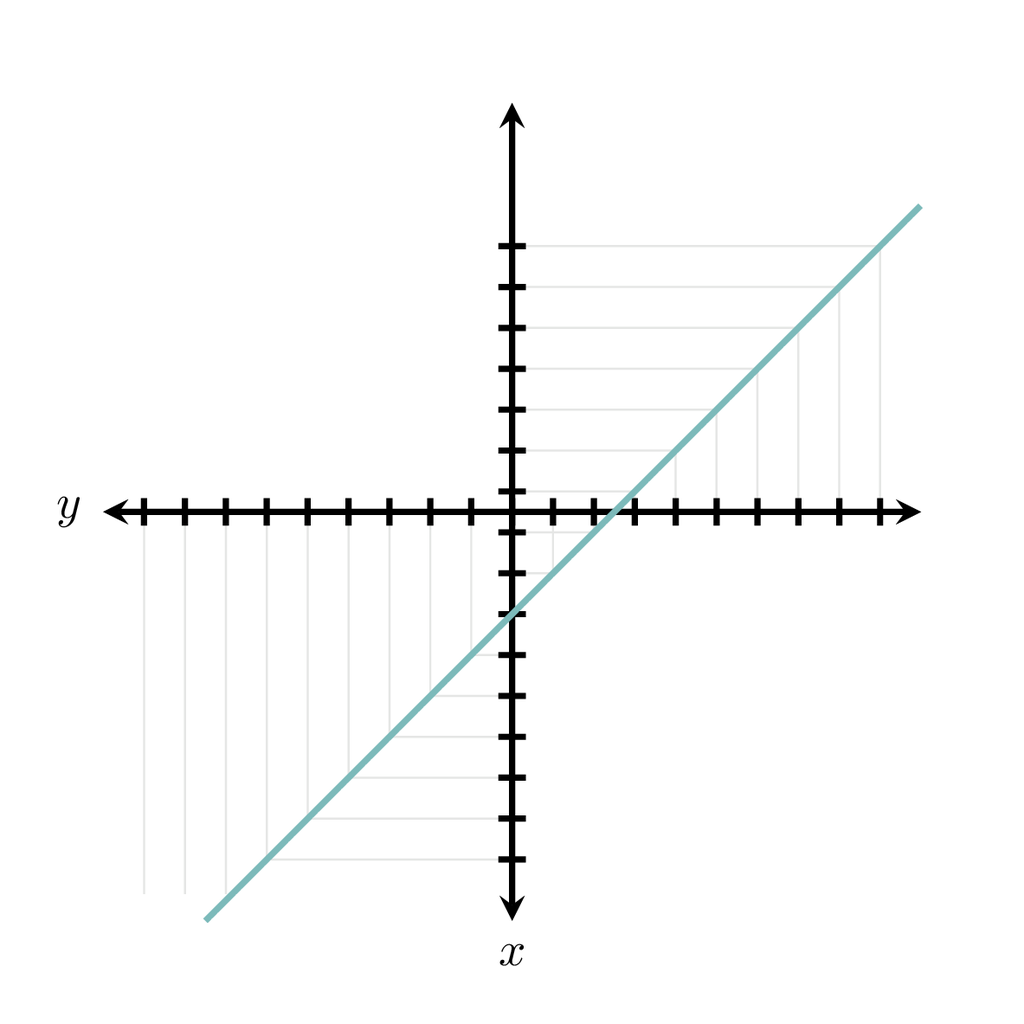

(a)

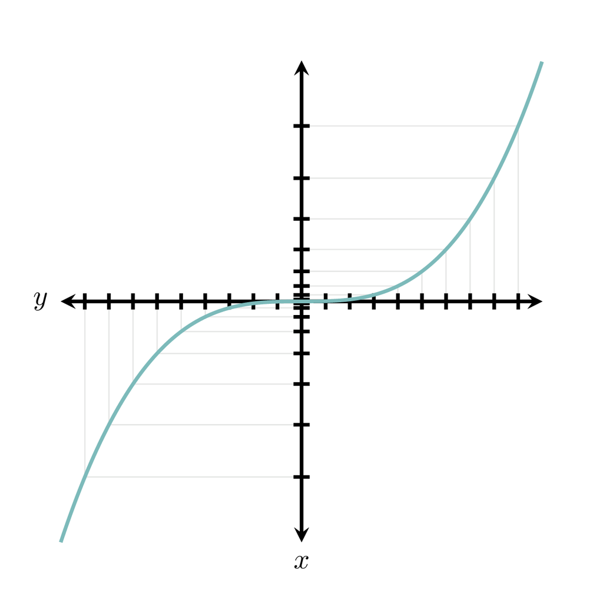

(b)

Figure 27: Isometries preserve the metric structure of the input and output spaces, ensuring that equally spaced input elements map into equally spaced output elements. When the input and output space are real lines (a) linear functions define isometries and where as (b) nonlinear functions do not.

#### 3.2.3.4 Topology-Preserving Relations

Bijections that respect any topological structure endowed to the input and output sets are denoted **homeomorphisms** which, unfortunately, we have to avoid confusing with algebra-preserving *homomorphisms*. Etymologically “homomorphism” is derived from the Greek for “same shape” while “homeomorphism” is derived from the Greek for “similar shape” which have almost equivalent meanings. Contemporary mathematics, however, has adopted a convention where the two terms are used exclusively to refer to algebraic and topological structure, respectively.

More formally, a bijective function is a homeomorphism if every subset in the input topology pushes forward to a subset in the output topology and vice versa. In other words, neighborhoods are preserved and input elements in proximity to each other are mapped into output elements that are also in proximity to each other, preserving notions of continuity of the space. Consequently, homeomorphisms are also known as invertible **continuous** functions.

In Section 1.2.4.3, we saw that lines and circles can be constructed from a common set equipped with different topologies. We can construct bijections between the underlying set elements, but any homeomorphism will preserve the shape induced by the initial topology, mapping lines into lines or circles into circles. Only non-homeomorphic bijections are capable of transforming the defining topologies, and hence a line into a circle or vice versa (Figure 28).

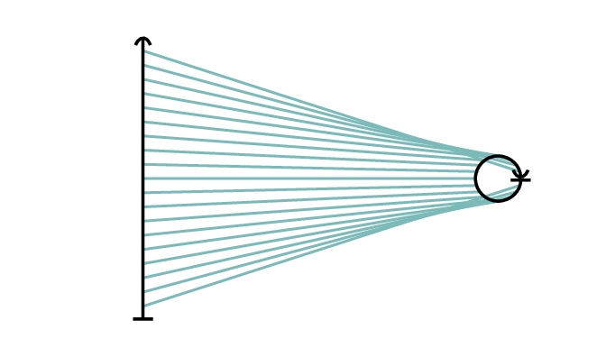

Figure 28: A line and a circle can be build from a common set, but require distinct topologies to give them their characteristic shapes. Because homeomorphisms cannot modify these topologies, they can map only lines into lines and circles into circles but not lines into circles. Any bijection from the elements that comprise a line and the elements that comprise a circle cannot be homeomorphic.

### 3.2.4 Reparameterizations

The ambiguity in how we can interpret the integers and the real line as spaces that we encountered in Section 2 also implies an ambiguity in how we interpret transformations between them.

Consider, for example, if we take the rigid real line perspective where there is not a single real line but rather a collection of distinct real lines, each with their own defining ordering, algebra, and metric. In general, a homeomorphism will transform one of these rigid real lines into another, but only the exceptional monotonically-increasing, homomorphic, and isometric homeomorphisms will map one of these rigid real lines into itself.

Conversely, we can take the flexible real line perspective where we treat the real line as a flexible space defined by a fixed set and topology but varying orderings, algebras, and metrics. From this perspective, homeomorphisms maintain the defining structure but generally transform the auxiliary structures. In other words, a homeomorphism will in general map one configuration of the flexible real line into another, *reconfiguring* the flexible real line. Because configurations are also known as parameterizations, the homeomorphic transformations are also known as **reparameterizations**. The exceptional monotonically-increasing, homomorphic, and isometric homeomorphisms map a parameterization into itself, preserving the initial configuration of the flexible real line.

While this interpretational ambiguity is often taken for granted, it have practical consequences. For example, we can interpret transformations of a physical system as *active* or *passive*. An active transformation is interpreted as changing the physical system, while a passive transformation is interpreted as changing how we represent a fixed physical system. These two views parallel the rigid and flexible real line perspectives, respectively. Both interpretations yield equivalent results, but one can be more natural than the other in some contexts.

Consider, for instance, using a real-valued variable to quantify some property of a physical system. In this case transforming from one real line to another can be interpreted in one of two ways. An active transformation corresponds to stretching the physical system while keeping our rulers fixed, while a passive transformation can be interpreted as keeping the physical system fixed while changing the *units* of the ruler (Figure 29).

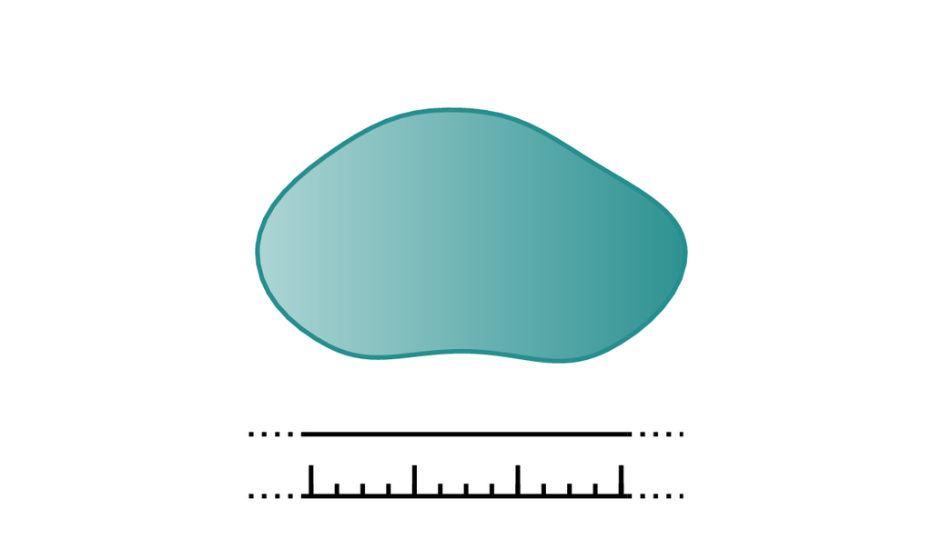

(a)

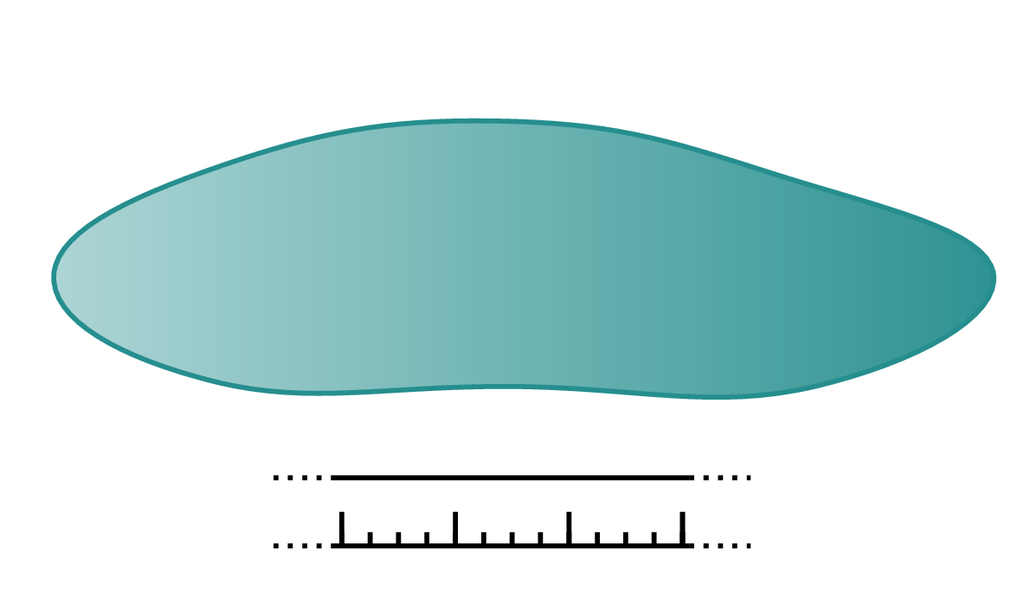

(b)

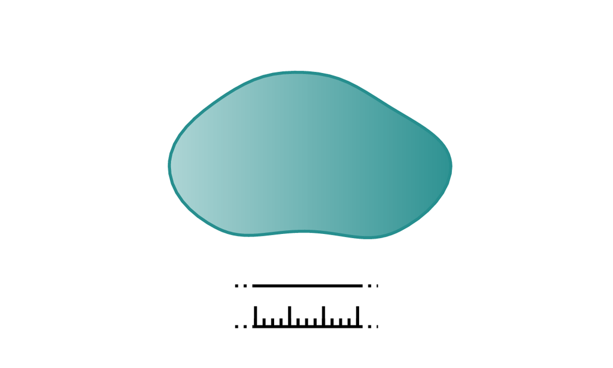

(c)

Figure 29: When we use a real number to quantify some aspect of a system (a) we can interpret the real line as a ruler. Transformations of the ambient space can then be interpreted in one of two equivalent ways. (b) An active transformation is interpreted as warping of the system while the ruler remains fixed. (c) The equivalent passive transformation is interpreted as warping the ruler while the physical system remains fixed. Active transformations are well-aligned with the rigid real line perspective, while passive transformations well-aligned with the flexible real line perspective.

At the same time, we find can find similar ambiguities in language. We might interpret text written in a particular language as fundamental, in which case *translations* from one language to another map one text to another. That said, we might also interpret these texts as *representations* of some universal statement, in which case translations don’t change the statement but do change its representation.

Similarly, we have the freedom to interpret computer programs written in different programming languages as either distinct programs or different implementations of some fixed program with universal inputs and outputs. In the former interpretation *transpilers* map from one program to another, but in the latter they map from one implementation to another.

These interpretations are equivalent, and we are free to adopt the one that is most useful in any given application. In this book I will tend to default to the flexible real line perspective, where the real line can be configured infinitely many ways.

# 4 Conclusion

Spaces are one of those ubiquitous mathematical concepts that are often taken for granted. While this can be adequate for more heuristic mathematical modeling tasks, it does leave us open to some existential crises if we look a little bit too closely and start asking, for example, what exactly a reparameterization is.

In this chapter we’ve surveyed the formal construction of spaces, from an underlying set to the many structures that can endow that set with useful properties, and their transformations. Along the way, we took a careful look at familiar concepts like variables while also digging into some more complicated concepts like topology, taking care to appreciate how they can be useful beyond just theoretical mathematics. This understanding will provide a strong foundation on which we introduce probability theory in its full generality, and hence full power.

There are a wealth of resources for those interested in exploring these topics more deeply, although finding the right resource is often a challenge. Many of the more accessible resources are prone to oversimplification, which can make it difficult to iterate to more technical resources. At the same time, more technical resources often jump directly into detail with little to no context for why the details might be relevant.

Personally I have found John Lee’s introductory writing to be a reasonable middle ground, especially the appendices and first few chapters of Lee (2011) and the appendices of Lee (2013). Similarly, I find that Curtis (1993) provides an accessible introduction to the more technical aspects of linear algebra. An additional benefit of these resources is that they can help acclimate one to the writing style particular to theoretical mathematics, and make other resources a bit more accessible.

At the same time, the articles on [Wikipedia](https://en.wikipedia.org/wiki/Mathematics) are continuously improving. I find these articles to be a particularly useful reference for delving into technical details on precise topics.

# Acknowledgements

I thank Simon Duane, Jerzy Baranowski, Ron Garcia, Stone Chen, Alexander Noll, Pietro Monticone, Tatsuo Okubo, Léo Burgund, and Francesco Terenzi for helpful comments and discussion.

A very special thanks to everyone supporting me on Patreon: Adam Fleischhacker, Adriano Yoshino, Alan Chang, Alessandro Varacca, Alexander Bartik, Alexander Noll, Alexander Petrov, Alexander Rosteck, Anders Valind, Andrea Serafino, Andrew Mascioli, Andrew Rouillard, Andrew Vigotsky, Angie_Hyunji Moon, Ara Winter, Austin Rochford, Austin Rochford, Avraham Adler, Ben Matthews, Ben Swallow, Benjamin Glemain, Bradley Kolb, Brynjolfur Gauti Jónsson, Cameron Smith, Canaan Breiss, Cat Shark, Charles Naylor, Chase Dwelle, Chris Zawora, Christopher Mehrvarzi, Chuck Carlson, Colin Carroll, Colin McAuliffe, Cruz, Damien Mannion, Damon Bayer, dan mackinlay, Dan Muck, Dan W Joyce, Dan Waxman, Dan Weitzenfeld, Daniel Edward Marthaler, Daniel Rowe, Darshan Pandit, Darthmaluus , David Burdelski, David Galley, David Humeau, David Wurtz, dilsher singh dhillon, Doug Rivers, Dr. Jobo, Dr. Omri Har Shemesh, Ed Cashin, Ed Henry, Edgar Merkle, edith darin, Eric LaMotte, Erik Banek, Ero Carrera, Eugene O’Friel, Felipe González, Fergus Chadwick, Finn Lindgren, Florian Wellmann, Francesco Corona, Geoff Rollins, Greg Sutcliffe, Guido Biele, Hamed Bastan-Hagh, Haonan Zhu, Hector Munoz, Henri Wallen, hs, Hugo Botha, Håkan Johansson, Ian Costley, Ian Koller, idontgetoutmuch, Ignacio Vera, Ilaria Prosdocimi, Isaac Vock, J, J Michael Burgess, Jair Andrade, James Hodgson, James McInerney, James Wade, Janek Berger, Jason Martin, Jason Pekos, Jason Wong, Jeff Burnett, Jeff Dotson, Jeff Helzner, Jeffrey Erlich, Jesse Wolfhagen, Jessica Graves, Joe Wagner, John Flournoy, Jonathan H. Morgan, Jonathon Vallejo, Joran Jongerling, Joseph Despres, Josh Weinstock, Joshua Duncan, Joshua Griffith, Josué Mendoza, JU, Justin Bois, Karim Naguib, Karim Osman, Kejia Shi, Kevin Foley, Kristian Gårdhus Wichmann, Kádár András, lizzie , LOU ODETTE, Marc Dotson, Marcel Lüthi, Marek Kwiatkowski, Mark Donoghoe, Mark Worrall, Markus P., Martin Modrák, Matt Moores, Matthew, Matthew Kay, Matthieu LEROY, Maurits van der Meer, Merlin Noel Heidemanns, Michael DeWitt, Michael Dillon, Michael Lerner, Mick Cooney, Márton Vaitkus, N Sanders, Name, Nathaniel Burbank, Nic Fishman, Nicholas Clark, Nicholas Cowie, Nick S, Nicolas Frisby, Octavio Medina, Ole Rogeberg, Oliver Crook, Olivier Ma, Pablo León Villagrá, Patrick Kelley, Patrick Boehnke, Pau Pereira Batlle, Peter Smits, Pieter van den Berg , ptr, Putra Manggala, Ramiro Barrantes Reynolds, Ravin Kumar, Raúl Peralta Lozada, Riccardo Fusaroli, Richard Nerland, RLW, Robert Frost, Robert Goldman, Robert kohn, Robert Mitchell V, Robin Taylor, Ross McCullough, Ryan Grossman, Rémi , S Hong, Scott Block, Scott Brown, Sean Pinkney, Sean Wilson, Seth Axen, shira, Simon Duane, Simon Lilburn, Srivatsa Srinath, sssz, Stan_user, Stefan, Stephanie Fitzgerald, Stephen Lienhard, Steve Bertolani, Stone Chen, Susan Holmes, Svilup, Sören Berg, Tao Ye, Tate Tunstall, Tatsuo Okubo, Teresa Ortiz, Thomas Lees, Thomas Vladeck, Tiago Cabaço, Tim Radtke, Tobychev , Tom McEwen, Tony Wuersch, Utku Turk, Virginia Fisher, Vitaly Druker, Vladimir Markov, Wil Yegelwel, Will Farr, Will Tudor-Evans, woejozney, Xianda Sun, yolhaj , yureq , Zach A, Zad Rafi, and Zhengchen Cai.

# References

Curtis, Charles W. 1993. *Linear Algebra*. Fourth. Undergraduate Texts in Mathematics. Springer-Verlag, New York.

Lee, John M. 2011. *Introduction to Topological Manifolds*. Springer.

———. 2013. *Introduction to Smooth Manifolds*. Springer.

# License

The text and figures in this chapter are copyrighted by Michael Betancourt and licensed under the CC BY-NC 4.0 license:

https://creativecommons.org/licenses/by-nc/4.0/